# CS 690U Project *2025*

# Diverse Genome Embedding Benchmark

Declaration of Intent: \

Basic Idea: Compare a simple model with a complex model from the DGEB paper in case of EC-Classification -> do we really need a complex foundation model?

Using AA (amino acids)

I will test or plot: \

The performance (e.g., F1-score) of a logistic regression model trained on one-hot encoded protein sequences for EC number prediction. I will also compare this performance to published results from foundation models in the DGEB benchmark.

If the hypothesis is true, I will observe: \

The logistic regression model will achieve comparable performance (in terms of F1-score) to the foundation model baseline on the EC Classification task, indicating that simple models can be effective with basic encodings.

If the hypothesis is false, I will observe:

The logistic regression model will perform significantly worse than the foundation models, suggesting that the complex, pre-trained representations are capturing important functional features that simple models miss.

### Idea:

#### Getting TSV -> Do One-Hot-Encoding -> Split -> train Modell -> test Model -> comapare Results with DGEB -> discussion

```python
#! pip install biopython scikit-learn pandas numpy
#! pip install dgeb
#! pip uninstall -y scipy
#! pip uninstall -y scikit-learn

# ! pip install scipy scikit-learn --force-reinstall --no-cache-dir
```

[output not shown]

```python
import scipy
print(scipy.__version__)
from sklearn.metrics import classification_report, ConfusionMatrixDisplay, f1_score, accuracy_score, precision_recall_fscore_support
from transformers import AutoTokenizer, AutoModel
import torch
import pandas as pd
import numpy as np
from sklearn.linear_model import LogisticRegression
from sklearn.model_selection import train_test_split
from sklearn.metrics import classification_report
import matplotlib.pyplot as plt
from sklearn.metrics import ConfusionMatrixDisplay
```

```
1.13.1
```

## Preperation of the Dataset

## Load Dataset

### UniProt Dataset

```python
tsv_file = "uniprotkb_ec_AND_reviewed_true_AND_frag_2025_04_10.tsv"
df = pd.read_csv(tsv_file, sep='\t')

# Just keep the relevant columns with exact one EC number
df = df[df['EC number'].notna()]
df = df[df['EC number'].apply(lambda x: ";" not in str(x))]
# print(df)

#  just keep classes with at least 5 sequences
df['EC_class'] = df['EC number']
class_counts = df['EC_class'].value_counts()
print(f"Anzahl:",class_counts)
valid_classes = class_counts[class_counts >= 5].index
df = df[df['EC_class'].isin(valid_classes)]

# Fit sequence length
max_len = 256 #512
aa_list = list("ACDEFGHIKLMNPQRSTVWY")
def clean_sequence(seq):
    seq = seq[:max_len]
    seq = ''.join([aa if aa in aa_list else 'X' for aa in seq])
    return seq.ljust(max_len, 'X')
df["CleanedSeq"] = df["Sequence"].apply(clean_sequence)

print(df["CleanedSeq"].head())
```

```
Anzahl: EC_class
7.1.1.-        4626
2.7.7.6        3943
3.1.-.-        3902
2.7.11.1       2420
2.1.1.-        2326
               ...
1.13.11.9         1
1.14.14.158       1
6.2.1.46          1
4.2.3.167         1
4.1.1.76          1
Name: count, Length: 5176, dtype: int64
1    MRFQVIVAAATITMITSYIPGVASQSTSDGDDLFVPVSNFDPKSIF...
3    MYRKLAVISAFLATARAQSACTLQSETHPPLTWQKCSSGGTCTQQT...
4    MRSLAILTTLLAGHAFAYPKPAPQSVNRRDWPSINEFLSELAKVMP...
5    MIVGILTTLATLATLAASVPLEERQACSSVWGQCGGQNWSGPTCCA...
6    MYWQLVRILVLFDCLQKILAIEHDSICIADVDDACPEPSHTVMRLR...
Name: CleanedSeq, dtype: object
```

```python
# Note: 2378 classes were too much to train the model ( time > 1h)
top_classes = df['EC_class'].value_counts().head(100).index
df = df[df['EC_class'].isin(top_classes)]
```

### Hot-Encoding

```python
# One-Hot-Encoding
def one_hot_encode_sequence(seq):
    matrix = np.zeros((max_len, 21))
    for i, aa in enumerate(seq):
        idx = aa_list.index(aa) if aa in aa_list else 20
        matrix[i, idx] = 1
    return matrix.flatten()

X = np.stack(df["CleanedSeq"].apply(one_hot_encode_sequence))
y = df["EC_class"].values

print("Dataset successfully computed.")
print("Input shape:", X.shape)
print("Number of classes:", len(set(y)))
```

```
Dataset successfully computed.
Input shape: (95590, 5376)
Number of classes: 100
```

### Split-up Dataset

```python
# Split the data into training and test sets
X_train, X_test, y_train, y_test = train_test_split(
    X, y, test_size=0.2, random_state=42, stratify=y
)
X_train_customDS = X_train
X_test_customDS = X_test
y_train_customDS = y_train
y_test_customDS = y_test
```

## Logistic Regression

Setup and train model

```python
model = LogisticRegression(max_iter=500, solver='saga', multi_class='multinomial', verbose=1)
# Klassifikationsmodell trainieren
model.fit(X_train, y_train)
```

```
Epoch 1, change: 1
Epoch 2, change: 0.3000886
Epoch 3, change: 0.17558489
```

```python
#better safe than sorry
np.save('X_train_UniProt.npy', X_train)
np.save('X_test_UniProt.npy', X_test)
np.save('y_train_UniProt.npy', y_train)
np.save('y_test_UniProt.npy', y_test)
```

### Result evalutation

```python
y_pred = model.predict(X_test)
print(classification_report(y_test, y_pred))
```

[output not shown]

[output cut: 79 more lines]

[output not shown]

### Test Model performance

[figure not shown]

```python
# Confusion Matrix
ConfusionMatrixDisplay.from_estimator(model, X_test, y_test)
plt.xticks(rotation=90)
plt.show()
```

[figure not shown]

[output not shown]

```python
#Ergebnis-Plot: F1-Score und Accuracy
f1 = f1_score(y_test, y_pred, average='weighted')
acc = accuracy_score(y_test, y_pred)

plt.figure(figsize=(6,4))
plt.bar(['F1-Score', 'Accuracy'], [f1, acc], color=['skyblue', 'lightgreen'])
plt.ylim(0,1)
plt.title('Model Performance')
plt.ylabel('Score')
plt.show()

print("F1-Score:", f1)
print("Accuracy:", acc)
```

```python
# Save model
import joblib
joblib.dump(model, 'ec_model.joblib')
print("Model saved as ec_model.joblib")
```

```
Model saved as ec_model.joblib
```

## Load Dataset from Huggingface

```python
from datasets import load_dataset

dataset = load_dataset("tattabio/ec_classification")
train_data = dataset["train"]
test_data = dataset["test"]
```

## Hot-Endcoding

```python
# define acid_list
aa_list = list("ACDEFGHIKLMNPQRSTVWY")
max_len = 256 #512

def clean_and_encode(seq):
    seq = seq[:max_len]
    seq = ''.join([aa if aa in aa_list else 'X' for aa in seq])
    seq = seq.ljust(max_len, 'X')
    one_hot = np.zeros((max_len, 21))
    for i, aa in enumerate(seq):
        idx = aa_list.index(aa) if aa in aa_list else 20
        one_hot[i, idx] = 1
    return one_hot.flatten()
```

## Prepare Dataset

```python
# trainng dataset
X_train = np.stack([clean_and_encode(x['Sequence']) for x in train_data])
y_train = [x['Label'] for x in train_data]

# test dataset
X_test = np.stack([clean_and_encode(x['Sequence']) for x in test_data])
y_test = [x['Label'] for x in test_data]

print("Trainingsdaten:", X_train.shape, y_train[:5])
print("Testdaten:", X_test.shape, y_test[:5])

print(len(X_train))
print(len(X_test))
print(len(y_train))
print(len(y_test))
```

```
Trainingsdaten: (512, 5376) ['1.14.14.18', '1.14.14.18', '1.14.14.18', '1.14.14.18', '1.15.1.1']
Testdaten: (128, 5376) ['1.14.14.18', '1.15.1.1', '1.16.3.1', '1.17.4.1', '1.5.98.3']
512
128
512
128
```

## Logistic Regression

Setup and train model

```python
from sklearn.linear_model import LogisticRegression

model = LogisticRegression(max_iter=500, solver='saga', multi_class='multinomial', verbose=1)
# Klassifikationsmodell trainieren
model.fit(X_train, y_train)
```

```
Epoch 1, change: 1
Epoch 2, change: 0.43071083
Epoch 3, change: 0.30358071
Epoch 4, change: 0.27010064
Epoch 5, change: 0.19719495
Epoch 6, change: 0.14770431
Epoch 7, change: 0.092806506
Epoch 8, change: 0.077321722
Epoch 9, change: 0.0455733
Epoch 10, change: 0.10647889
Epoch 11, change: 0.062587379
Epoch 12, change: 0.062503919
Epoch 13, change: 0.037817683
Epoch 14, change: 0.030875078
Epoch 15, change: 0.026905791
Epoch 16, change: 0.025366777
Epoch 17, change: 0.024550922
Epoch 18, change: 0.013840921
Epoch 19, change: 0.011564019
Epoch 20, change: 0.0093062622
Epoch 21, change: 0.0096978461
Epoch 22, change: 0.0084029306
Epoch 23, change: 0.0081908132
Epoch 24, change: 0.0072542217
Epoch 25, change: 0.0068421576
Epoch 26, change: 0.0068877101
Epoch 27, change: 0.006885632
Epoch 28, change: 0.0056290849
Epoch 29, change: 0.0059117078
Epoch 30, change: 0.0050250547
Epoch 31, change: 0.0046516523
Epoch 32, change: 0.0041534537
Epoch 33, change: 0.0041443156
Epoch 34, change: 0.0039978837
Epoch 35, change: 0.0033257103
Epoch 36, change: 0.0034088284
Epoch 37, change: 0.0032266301
Epoch 38, change: 0.0031914127
Epoch 39, change: 0.0031574909
Epoch 40, change: 0.0031236228
```

[output cut: 180 more lines]

```
Epoch 221, change: 0.0001175666
Epoch 222, change: 0.00011641687
Epoch 223, change: 0.00011487017
Epoch 224, change: 0.0001131049
Epoch 225, change: 0.00011184489
Epoch 226, change: 0.00011082138
Epoch 227, change: 0.00010925085
Epoch 228, change: 0.00010759726
Epoch 229, change: 0.00010679269
Epoch 230, change: 0.00010518406
Epoch 231, change: 0.00010461578
Epoch 232, change: 0.00010317537
Epoch 233, change: 0.00010160392
Epoch 234, change: 0.00010043816
convergence after 235 epochs took 229 seconds
```

```
LogisticRegression(max_iter=500, multi_class='multinomial', solver='saga',
                   verbose=1)
```

```python
#better safe than sorry
np.save('X_train.npy', X_train)
np.save('X_test.npy', X_test)
np.save('y_train.npy', y_train)
np.save('y_test.npy', y_test)
```

### Result evalutation

```python
from sklearn.metrics import classification_report

y_pred = model.predict(X_test)

print(classification_report(y_test, y_pred))
```

```
              precision    recall  f1-score   support

  1.14.14.18       0.00      0.00      0.00         1
    1.15.1.1       0.00      0.00      0.00         1
    1.16.3.1       0.50      1.00      0.67         1
    1.17.4.1       0.00      0.00      0.00         1
    1.5.98.3       0.00      0.00      0.00         1
     1.8.3.2       0.00      0.00      0.00         1
   2.1.1.354       0.00      0.00      0.00         1
   2.1.1.360       0.00      0.00      0.00         1
    2.1.1.37       0.00      0.00      0.00         1
    2.1.1.72       0.00      0.00      0.00         1
    2.1.1.77       0.20      1.00      0.33         1
    2.1.1.86       0.00      0.00      0.00         1
    2.1.3.15       0.00      0.00      0.00         1
   2.3.1.225       1.00      1.00      1.00         1
   2.3.1.269       0.00      0.00      0.00         1
    2.3.1.48       0.00      0.00      0.00         1
    2.3.1.51       0.00      0.00      0.00         1
    2.3.2.23       0.00      0.00      0.00         1
    2.3.2.26       0.33      1.00      0.50         1
    2.3.2.27       0.00      0.00      0.00         1
    2.3.2.31       0.00      0.00      0.00         1
   2.4.1.109       0.00      0.00      0.00         1
   2.4.1.198       0.00      0.00      0.00         1
    2.4.2.31       0.00      0.00      0.00         1
    2.5.1.18       0.00      0.00      0.00         1
   2.7.1.107       0.00      0.00      0.00         1
    2.7.1.21       0.00      0.00      0.00         1
    2.7.1.33       0.00      0.00      0.00         1
    2.7.1.67       0.00      0.00      0.00         1
    2.7.10.1       0.00      0.00      0.00         1
    2.7.10.2       0.00      0.00      0.00         1
    2.7.11.1       0.00      0.00      0.00         1
   2.7.11.25       0.20      1.00      0.33         1
    2.7.13.3       0.00      0.00      0.00         1
     2.7.4.3       0.00      0.00      0.00         1
     2.7.6.1       0.00      0.00      0.00         1
   2.7.7.108       0.00      0.00      0.00         1
    2.7.7.19       0.00      0.00      0.00         1
```

[output cut: 79 more lines]

```
     6.3.2.4       0.00      0.00      0.00         1
    6.3.4.19       0.00      0.00      0.00         1
     6.3.5.2       0.00      0.00      0.00         1
     6.3.5.5       1.00      1.00      1.00         1
     6.5.1.1       0.00      0.00      0.00         1
     6.5.1.3       0.00      0.00      0.00         1
     7.1.1.2       0.00      0.00      0.00         1
     7.1.1.8       0.00      0.00      0.00         1
     7.1.1.9       0.00      0.00      0.00         1
     7.1.2.2       0.00      0.00      0.00         1
     7.2.1.1       0.00      0.00      0.00         1

    accuracy                           0.09       128
   macro avg       0.05      0.09      0.06       128
weighted avg       0.05      0.09      0.06       128
```

### Test Model performance

[figure not shown]

```python
import matplotlib.pyplot as plt
from sklearn.metrics import ConfusionMatrixDisplay

# Confusion Matrix
ConfusionMatrixDisplay.from_estimator(model, X_test, y_test)
plt.xticks(rotation=90)
plt.show()
```

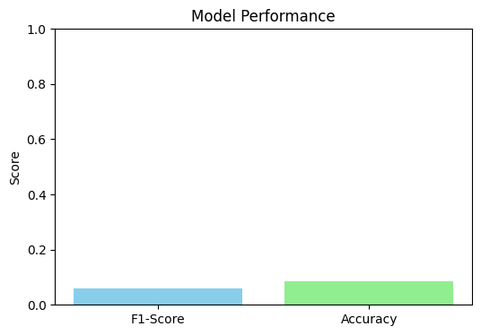

```
F1-Score: 0.05989583333333333
Accuracy: 0.0859375
```

```python
# Result-Plot: F1-Score und Accuracy
f1 = f1_score(y_test, y_pred, average='weighted')
acc = accuracy_score(y_test, y_pred)

plt.figure(figsize=(6,4))
plt.bar(['F1-Score', 'Accuracy'], [f1, acc], color=['skyblue', 'lightgreen'])
plt.ylim(0,1)
plt.title('Model Performance')
plt.ylabel('Score')
plt.show()

print("F1-Score:", f1)
print("Accuracy:", acc)
```

```python
# Save model
import joblib
joblib.dump(model, 'ec_model.joblib')
print("Model saved as ec_model.joblib")
```

```
Model saved as ec_model.joblib
```

# Train logistic regression models with different values of reularization strenght (C)

## Train model with different C values

```python
# Define values for C (inverse of regularization strength)
C_values = [0.01, 0.1, 1, 10, 100]
accuracy_scores = []
f1_scores = []

for C in C_values:
    model = LogisticRegression(
        solver='saga',
        multi_class='multinomial',
        max_iter=300,
        C=C,
        penalty='l2',
        verbose=0
    )
    model.fit(X_train, y_train)
    y_pred = model.predict(X_test)

    acc = accuracy_score(y_test, y_pred)
    f1 = f1_score(y_test, y_pred, average='weighted')

    accuracy_scores.append(acc)
    f1_scores.append(f1)
    print(f"C = {C:<6} → Accuracy = {acc:.4f}, F1-Score = {f1:.4f}")
```

```
C = 0.01   → Accuracy = 0.0547, F1-Score = 0.0283
```

```
C = 0.1    → Accuracy = 0.0859, F1-Score = 0.0599
C = 1      → Accuracy = 0.0859, F1-Score = 0.0599
```

```
C = 10     → Accuracy = 0.0781, F1-Score = 0.0514
C = 100    → Accuracy = 0.0703, F1-Score = 0.0436
```

## Evaluation

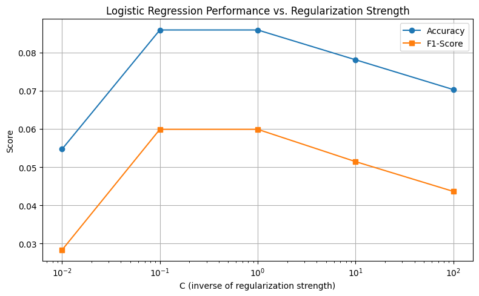

```python
plt.figure(figsize=(8, 5))
plt.plot(C_values, accuracy_scores, marker='o', label='Accuracy')
plt.plot(C_values, f1_scores, marker='s', label='F1-Score')
plt.xscale('log')  # log scale is common for regularization
plt.xlabel('C (inverse of regularization strength)')
plt.ylabel('Score')
plt.title('Logistic Regression Performance vs. Regularization Strength')
plt.legend()
plt.grid(True)
plt.tight_layout()
plt.show()
```

# Trying other enoding methods

## k-mer frequencies

```python
from sklearn.feature_extraction.text import CountVectorizer

# Prepare sequences as strings
sequences = [x['Sequence'] for x in train_data]  # from your huggingface dataset

# Define k
k = 3  # 3-mer

# Create k-mer tokens from sequence
def seq_to_kmers(seq, k):
    return ' '.join([seq[i:i+k] for i in range(len(seq)-k+1)])

kmers = [seq_to_kmers(seq, k) for seq in sequences]

# Count frequency of each k-mer
vectorizer = CountVectorizer()
X_train = vectorizer.fit_transform(kmers)

print("Shape of Feature Matrix:", X_train.shape)
```

```
Shape of Feature Matrix: (512, 7986)
```

```python
sequences_test = [x['Sequence'] for x in test_data]
kmers_test = [seq_to_kmers(seq, k) for seq in sequences_test]
X_test = vectorizer.transform(kmers_test)
```

## Logistic Regression

Setup and train model

```python
from sklearn.linear_model import LogisticRegression

model = LogisticRegression(max_iter=500, solver='saga', multi_class='multinomial', C=0.1, verbose=1)
# Klassifikationsmodell trainieren
model.fit(X_train, y_train)
```

```
Epoch 1, change: 1
Epoch 2, change: 0.45378242
Epoch 3, change: 0.27358075
Epoch 4, change: 0.22511615
Epoch 5, change: 0.14311151
Epoch 6, change: 0.12305695
Epoch 7, change: 0.11305456
Epoch 8, change: 0.062747186
Epoch 9, change: 0.055638912
Epoch 10, change: 0.048084126
Epoch 11, change: 0.056927255
Epoch 12, change: 0.027057044
Epoch 13, change: 0.024994897
Epoch 14, change: 0.01809176
Epoch 15, change: 0.019658634
Epoch 16, change: 0.014534352
Epoch 17, change: 0.014924772
Epoch 18, change: 0.011722676
Epoch 19, change: 0.012346263
Epoch 20, change: 0.011838062
Epoch 21, change: 0.011191884
Epoch 22, change: 0.0091671033
Epoch 23, change: 0.0079999822
Epoch 24, change: 0.0083330926
Epoch 25, change: 0.00753895
Epoch 26, change: 0.0067818045
Epoch 27, change: 0.0070514842
Epoch 28, change: 0.0061054149
Epoch 29, change: 0.0061729374
Epoch 30, change: 0.005130764
Epoch 31, change: 0.0047472789
Epoch 32, change: 0.004981629
Epoch 33, change: 0.0047865694
Epoch 34, change: 0.0042141779
Epoch 35, change: 0.0042586396
Epoch 36, change: 0.0041635018
Epoch 37, change: 0.0030344354
Epoch 38, change: 0.0032561462
Epoch 39, change: 0.0030574572
Epoch 40, change: 0.0030396331
```

[output cut: 161 more lines]

```
Epoch 202, change: 0.00013498184
Epoch 203, change: 0.00013227701
Epoch 204, change: 0.00012867717
Epoch 205, change: 0.00012523158
Epoch 206, change: 0.0001226114
Epoch 207, change: 0.00011972365
Epoch 208, change: 0.00011946361
Epoch 209, change: 0.00011501576
Epoch 210, change: 0.00011237413
Epoch 211, change: 0.00011055124
Epoch 212, change: 0.00010716895
Epoch 213, change: 0.00010601603
Epoch 214, change: 0.00010269322
Epoch 215, change: 0.00010059382
convergence after 216 epochs took 209 seconds
```

[output not shown]

```python
#better safe than sorry
np.save('X_train.npy', X_train)
np.save('X_test.npy', X_test)
np.save('y_train.npy', y_train)
np.save('y_test.npy', y_test)
```

### Result evalutation

```python
from sklearn.metrics import classification_report

y_pred = model.predict(X_test)

print(classification_report(y_test, y_pred))
```

```
              precision    recall  f1-score   support

  1.14.14.18       0.00      0.00      0.00         1
    1.15.1.1       0.00      0.00      0.00         1
    1.16.3.1       0.00      0.00      0.00         1
    1.17.4.1       0.00      0.00      0.00         1
    1.5.98.3       0.00      0.00      0.00         1
     1.8.3.2       0.00      0.00      0.00         1
   2.1.1.354       0.00      0.00      0.00         1
   2.1.1.360       0.00      0.00      0.00         1
    2.1.1.37       1.00      1.00      1.00         1
    2.1.1.72       0.00      0.00      0.00         1
    2.1.1.77       0.33      1.00      0.50         1
    2.1.1.86       1.00      1.00      1.00         1
    2.1.3.15       0.00      0.00      0.00         1
   2.3.1.225       0.00      0.00      0.00         1
   2.3.1.269       0.33      1.00      0.50         1
    2.3.1.48       0.00      0.00      0.00         1
    2.3.1.51       0.50      1.00      0.67         1
    2.3.2.23       1.00      1.00      1.00         1
    2.3.2.26       0.00      0.00      0.00         1
    2.3.2.27       0.00      0.00      0.00         1
    2.3.2.31       0.00      0.00      0.00         1
   2.4.1.109       0.00      0.00      0.00         1
   2.4.1.198       0.00      0.00      0.00         1
    2.4.2.31       0.00      0.00      0.00         1
    2.5.1.18       0.00      0.00      0.00         1
   2.7.1.107       0.00      0.00      0.00         1
    2.7.1.21       0.00      0.00      0.00         1
    2.7.1.33       0.50      1.00      0.67         1
    2.7.1.67       0.00      0.00      0.00         1
    2.7.10.1       0.00      0.00      0.00         1
    2.7.10.2       0.00      0.00      0.00         1
    2.7.11.1       0.00      0.00      0.00         1
   2.7.11.25       0.00      0.00      0.00         1
    2.7.13.3       0.00      0.00      0.00         1
     2.7.4.3       0.25      1.00      0.40         1
     2.7.6.1       1.00      1.00      1.00         1
   2.7.7.108       1.00      1.00      1.00         1
    2.7.7.19       0.00      0.00      0.00         1
```

[output cut: 79 more lines]

```
     6.3.2.4       0.25      1.00      0.40         1
    6.3.4.19       0.00      0.00      0.00         1
     6.3.5.2       1.00      1.00      1.00         1
     6.3.5.5       1.00      1.00      1.00         1
     6.5.1.1       0.00      0.00      0.00         1
     6.5.1.3       0.00      0.00      0.00         1
     7.1.1.2       0.00      0.00      0.00         1
     7.1.1.8       0.00      0.00      0.00         1
     7.1.1.9       0.00      0.00      0.00         1
     7.1.2.2       0.00      0.00      0.00         1
     7.2.1.1       0.00      0.00      0.00         1

    accuracy                           0.20       128
   macro avg       0.14      0.20      0.15       128
weighted avg       0.14      0.20      0.15       128
```

### Test Model performance

[figure not shown]

```python
import matplotlib.pyplot as plt
from sklearn.metrics import ConfusionMatrixDisplay

# 9. Confusion Matrix
ConfusionMatrixDisplay.from_estimator(model, X_test, y_test)
plt.xticks(rotation=90)
plt.show()
```

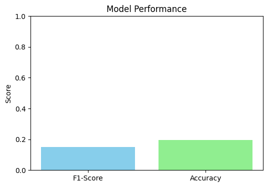

```
F1-Score: 0.15130208333333334
Accuracy: 0.1953125
```

```python
# Result-Plot: F1-Score und Accuracy
f1 = f1_score(y_test, y_pred, average='weighted')
acc = accuracy_score(y_test, y_pred)

plt.figure(figsize=(6,4))
plt.bar(['F1-Score', 'Accuracy'], [f1, acc], color=['skyblue', 'lightgreen'])
plt.ylim(0,1)
plt.title('Model Performance')
plt.ylabel('Score')
plt.show()

print("F1-Score:", f1)
print("Accuracy:", acc)
```

```python
# Save model
import joblib
joblib.dump(model, 'ec_model.joblib')
print("Model saved as ec_model.joblib")
```

```
Model saved as ec_model.joblib
```

# Comparison with the models from DGEB ESM2

```python
#! pip install dgeb
! pip install transformers datasets torch
```

[output not shown]

## Load Dataset

```python
from datasets import load_dataset

dataset = load_dataset("tattabio/ec_classification")
train_data = dataset["train"]
test_data = dataset["test"]
```

## Load ESM2 model & tokenizer

```python
model_name = "facebook/esm2_t6_8M_UR50D"

tokenizer = AutoTokenizer.from_pretrained(model_name)
model = AutoModel.from_pretrained(model_name)
model.eval()  # disable training mode
```

```
Some weights of EsmModel were not initialized from the model checkpoint at facebook/esm2_t6_8M_UR50D and are newly initialized: ['pooler.dense.bias', 'pooler.dense.weight']
You should probably TRAIN this model on a down-stream task to be able to use it for predictions and inference.
```

[output not shown]

## Define embedding function (mean pooling)

```python
def get_esm2_embedding(sequence):
    inputs = tokenizer(sequence, return_tensors="pt", truncation=True)
    with torch.no_grad():
        outputs = model(**inputs)
    # Average pooling over token embeddings
    embedding = outputs.last_hidden_state.mean(dim=1)
    return embedding[0].numpy()
```

## Apply to training & test sequences

## DGEB Data Set

```python
# Convert huggingface datasets to lists
train_sequences = [x["Sequence"] for x in train_data]
train_labels = [x["Label"] for x in train_data]

test_sequences = [x["Sequence"] for x in test_data]
test_labels = [x["Label"] for x in test_data]

# Generate embeddings
X_train_embed = np.stack([get_esm2_embedding(seq) for seq in train_sequences])
X_test_embed = np.stack([get_esm2_embedding(seq) for seq in test_sequences])
```

```
Asking to truncate to max_length but no maximum length is provided and the model has no predefined maximum length. Default to no truncation.
```

## Train classifier

```python
model = LogisticRegression(max_iter=500, solver='saga', multi_class='multinomial')
model.fit(X_train_embed, train_labels)

y_pred = model.predict(X_test_embed)
print(classification_report(test_labels, y_pred))
```

```
              precision    recall  f1-score   support

  1.14.14.18       0.00      0.00      0.00         1
    1.15.1.1       1.00      1.00      1.00         1
    1.16.3.1       0.00      0.00      0.00         1
    1.17.4.1       1.00      1.00      1.00         1
    1.5.98.3       0.00      0.00      0.00         1
     1.8.3.2       0.00      0.00      0.00         1
   2.1.1.354       0.00      0.00      0.00         1
   2.1.1.360       0.00      0.00      0.00         1
    2.1.1.37       0.50      1.00      0.67         1
    2.1.1.72       0.00      0.00      0.00         1
    2.1.1.77       1.00      1.00      1.00         1
    2.1.1.86       0.50      1.00      0.67         1
    2.1.3.15       0.00      0.00      0.00         1
   2.3.1.225       0.00      0.00      0.00         1
   2.3.1.269       1.00      1.00      1.00         1
    2.3.1.48       0.00      0.00      0.00         1
    2.3.1.51       1.00      1.00      1.00         1
    2.3.2.23       0.00      0.00      0.00         1
    2.3.2.26       0.17      1.00      0.29         1
    2.3.2.27       0.00      0.00      0.00         1
    2.3.2.31       0.00      0.00      0.00         1
   2.4.1.109       1.00      1.00      1.00         1
   2.4.1.198       0.33      1.00      0.50         1
    2.4.2.31       0.00      0.00      0.00         1
    2.5.1.18       1.00      1.00      1.00         1
   2.7.1.107       0.00      0.00      0.00         1
    2.7.1.21       0.00      0.00      0.00         1
    2.7.1.33       0.50      1.00      0.67         1
    2.7.1.67       0.00      0.00      0.00         1
    2.7.10.1       0.50      1.00      0.67         1
    2.7.10.2       0.00      0.00      0.00         1
    2.7.11.1       0.00      0.00      0.00         1
   2.7.11.25       0.00      0.00      0.00         1
    2.7.13.3       0.00      0.00      0.00         1
     2.7.4.3       1.00      1.00      1.00         1
     2.7.6.1       1.00      1.00      1.00         1
   2.7.7.108       0.50      1.00      0.67         1
    2.7.7.19       0.00      0.00      0.00         1
```

[output cut: 79 more lines]

```
     6.3.2.4       1.00      1.00      1.00         1
    6.3.4.19       1.00      1.00      1.00         1
     6.3.5.2       1.00      1.00      1.00         1
     6.3.5.5       1.00      1.00      1.00         1
     6.5.1.1       0.00      0.00      0.00         1
     6.5.1.3       0.00      0.00      0.00         1
     7.1.1.2       0.00      0.00      0.00         1
     7.1.1.8       1.00      1.00      1.00         1
     7.1.1.9       0.00      0.00      0.00         1
     7.1.2.2       0.00      0.00      0.00         1
     7.2.1.1       0.00      0.00      0.00         1

    accuracy                           0.44       128
   macro avg       0.38      0.44      0.39       128
weighted avg       0.38      0.44      0.39       128
```

```
Accuracy: 43.75 %
F1-Score: 0.39415922619047616

Detailed classification report:
              precision    recall  f1-score   support

  1.14.14.18       0.00      0.00      0.00         1
    1.15.1.1       1.00      1.00      1.00         1
    1.16.3.1       0.00      0.00      0.00         1
    1.17.4.1       1.00      1.00      1.00         1
    1.5.98.3       0.00      0.00      0.00         1
     1.8.3.2       0.00      0.00      0.00         1
   2.1.1.354       0.00      0.00      0.00         1
   2.1.1.360       0.00      0.00      0.00         1
    2.1.1.37       0.50      1.00      0.67         1
    2.1.1.72       0.00      0.00      0.00         1
    2.1.1.77       1.00      1.00      1.00         1
    2.1.1.86       0.50      1.00      0.67         1
    2.1.3.15       0.00      0.00      0.00         1
   2.3.1.225       0.00      0.00      0.00         1
   2.3.1.269       1.00      1.00      1.00         1
    2.3.1.48       0.00      0.00      0.00         1
    2.3.1.51       1.00      1.00      1.00         1
    2.3.2.23       0.00      0.00      0.00         1
    2.3.2.26       0.17      1.00      0.29         1
    2.3.2.27       0.00      0.00      0.00         1
    2.3.2.31       0.00      0.00      0.00         1
   2.4.1.109       1.00      1.00      1.00         1
   2.4.1.198       0.33      1.00      0.50         1
    2.4.2.31       0.00      0.00      0.00         1
    2.5.1.18       1.00      1.00      1.00         1
   2.7.1.107       0.00      0.00      0.00         1
    2.7.1.21       0.00      0.00      0.00         1
    2.7.1.33       0.50      1.00      0.67         1
    2.7.1.67       0.00      0.00      0.00         1
    2.7.10.1       0.50      1.00      0.67         1
    2.7.10.2       0.00      0.00      0.00         1
    2.7.11.1       0.00      0.00      0.00         1
   2.7.11.25       0.00      0.00      0.00         1
    2.7.13.3       0.00      0.00      0.00         1
```

[output cut: 83 more lines]

```
     6.3.2.4       1.00      1.00      1.00         1
    6.3.4.19       1.00      1.00      1.00         1
     6.3.5.2       1.00      1.00      1.00         1
     6.3.5.5       1.00      1.00      1.00         1
     6.5.1.1       0.00      0.00      0.00         1
     6.5.1.3       0.00      0.00      0.00         1
     7.1.1.2       0.00      0.00      0.00         1
     7.1.1.8       1.00      1.00      1.00         1
     7.1.1.9       0.00      0.00      0.00         1
     7.1.2.2       0.00      0.00      0.00         1
     7.2.1.1       0.00      0.00      0.00         1

    accuracy                           0.44       128
   macro avg       0.38      0.44      0.39       128
weighted avg       0.38      0.44      0.39       128
```

[figure not shown]

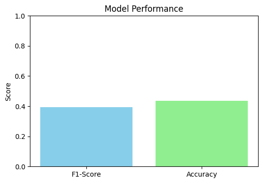

```
F1-Score: 0.39415922619047616
Accuracy: 0.4375
```

```python
# Evaluate Predictions
accuracy = accuracy_score(test_labels, y_pred)
f1 = f1_score(test_labels, y_pred, average='weighted')  # weighted = considers class imbalance

print("Accuracy:", accuracy * 100, "%")
print("F1-Score:", f1)

print("\nDetailed classification report:")
print(classification_report(test_labels, y_pred))

# Visualize confusion matrix
ConfusionMatrixDisplay.from_estimator(model, X_test_embed, test_labels)
plt.xticks(rotation=90)
plt.show()
# Plot F1-Score und Accuracy
f1 = f1_score(test_labels, y_pred, average='weighted')
acc = accuracy_score(test_labels, y_pred)

plt.figure(figsize=(6,4))
plt.bar(['F1-Score', 'Accuracy'], [f1, acc], color=['skyblue', 'lightgreen'])
plt.ylim(0,1)
plt.title('Model Performance')
plt.ylabel('Score')
plt.show()

print("F1-Score:", f1)
print("Accuracy:", acc)
```

## Custom Data Set

```python
model_customDS = LogisticRegression(max_iter=10, solver='saga', multi_class='multinomial', n_jobs=-1, verbose=1)
model_customDS.fit(X_train_customDS, y_train_customDS)
```

```
Epoch 1, change: 1
Epoch 2, change: 0.21424115
Epoch 3, change: 0.14630157
Epoch 4, change: 0.11512263
Epoch 5, change: 0.082461947
Epoch 6, change: 0.061499406
Epoch 7, change: 0.062505797
Epoch 8, change: 0.042685518
Epoch 9, change: 0.031628279
max_iter reached after 1089 secondsEpoch 10, change: 0.033246014
```

```
LogisticRegression(max_iter=10, multi_class='multinomial', n_jobs=-1,
                   solver='saga', verbose=1)
```

```python
y_pred_customDS = model_customDS.predict(X_test_customDS)
print(classification_report(y_test_customDS, y_pred_customDS))
```

```
              precision    recall  f1-score   support

     1.-.-.-       0.41      0.52      0.46       305
    1.1.1.86       1.00      1.00      1.00       127
    1.1.1.94       0.98      0.96      0.97       119
    1.14.-.-       0.81      0.72      0.76       165
     2.1.1.-       0.55      0.68      0.61       465
   2.1.1.177       1.00      0.97      0.98       124
   2.1.1.182       1.00      0.91      0.95       125
   2.1.1.192       0.97      0.87      0.92       127
   2.1.1.199       0.99      0.95      0.97       168
   2.1.1.228       1.00      0.87      0.93       141
     2.1.2.1       1.00      0.97      0.99       159
     2.1.2.9       1.00      0.96      0.98       136
    2.1.3.15       0.98      0.96      0.97       195
     2.1.3.2       1.00      0.94      0.97       141
     2.3.1.-       0.49      0.59      0.54       240
   2.3.1.234       1.00      0.94      0.97       150
    2.3.2.27       0.59      0.61      0.60       270
     2.4.1.-       0.45      0.41      0.43       177
   2.4.1.227       1.00      0.98      0.99       138
     2.4.2.7       0.98      0.97      0.98       129
     2.4.2.9       1.00      0.96      0.98       140
    2.5.1.19       0.98      0.94      0.96       118
     2.5.1.6       0.99      0.99      0.99       156
    2.5.1.75       0.97      0.93      0.95       158
    2.5.1.78       0.98      0.96      0.97       123
   2.7.1.148       0.98      0.94      0.96       117
    2.7.1.33       0.98      0.92      0.95       127
    2.7.11.1       0.48      0.63      0.54       484
     2.7.2.3       1.00      0.96      0.98       140
     2.7.4.3       0.99      0.93      0.96       174
     2.7.4.6       1.00      0.98      0.99       143
     2.7.4.9       0.98      0.97      0.98       123
     2.7.7.3       1.00      0.98      0.99       135
     2.7.7.6       0.87      0.91      0.89       789
     2.7.7.7       0.78      0.70      0.74       140
     2.7.7.8       1.00      0.96      0.98       157
    2.7.8.13       1.00      0.96      0.98       143
     2.7.8.7       1.00      0.92      0.96       119
```

[output cut: 51 more lines]

```
     6.3.4.5       1.00      1.00      1.00       121
     6.3.5.-       0.94      0.89      0.91       251
     6.3.5.2       1.00      0.92      0.96       132
     6.3.5.7       0.99      0.94      0.97       122
     6.5.1.2       0.98      0.93      0.95       175
     7.-.-.-       0.97      0.90      0.93       164
     7.1.1.-       0.90      0.93      0.92       925
     7.1.1.2       0.99      0.91      0.95       258
     7.1.1.9       1.00      0.80      0.89       139
     7.1.2.2       0.99      0.98      0.99       422
     7.4.2.8       1.00      0.93      0.97       168

    accuracy                           0.88     19118
   macro avg       0.93      0.90      0.91     19118
weighted avg       0.89      0.88      0.88     19118
```

### Safe model

```python
np.save("X_train_embed.npy", X_train_customDS)
np.save("X_test_embed.npy", X_test_customDS)
```

### Load model

```python
X_train_embed = np.load("X_train_embed.npy")
X_test_embed = np.load("X_test_embed.npy")
```

### Evaluate Predictions

```
Accuracy: 87.54576838581441 %
F1-Score: 0.8807537462237521

Detailed classification report:
              precision    recall  f1-score   support

     1.-.-.-       0.41      0.52      0.46       305
    1.1.1.86       1.00      1.00      1.00       127
    1.1.1.94       0.98      0.96      0.97       119
    1.14.-.-       0.81      0.72      0.76       165
     2.1.1.-       0.55      0.68      0.61       465
   2.1.1.177       1.00      0.97      0.98       124
   2.1.1.182       1.00      0.91      0.95       125
   2.1.1.192       0.97      0.87      0.92       127
   2.1.1.199       0.99      0.95      0.97       168
   2.1.1.228       1.00      0.87      0.93       141
     2.1.2.1       1.00      0.97      0.99       159
     2.1.2.9       1.00      0.96      0.98       136
    2.1.3.15       0.98      0.96      0.97       195
     2.1.3.2       1.00      0.94      0.97       141
     2.3.1.-       0.49      0.59      0.54       240
   2.3.1.234       1.00      0.94      0.97       150
    2.3.2.27       0.59      0.61      0.60       270
     2.4.1.-       0.45      0.41      0.43       177
   2.4.1.227       1.00      0.98      0.99       138
     2.4.2.7       0.98      0.97      0.98       129
     2.4.2.9       1.00      0.96      0.98       140
    2.5.1.19       0.98      0.94      0.96       118
     2.5.1.6       0.99      0.99      0.99       156
    2.5.1.75       0.97      0.93      0.95       158
    2.5.1.78       0.98      0.96      0.97       123
   2.7.1.148       0.98      0.94      0.96       117
    2.7.1.33       0.98      0.92      0.95       127
    2.7.11.1       0.48      0.63      0.54       484
     2.7.2.3       1.00      0.96      0.98       140
     2.7.4.3       0.99      0.93      0.96       174
     2.7.4.6       1.00      0.98      0.99       143
     2.7.4.9       0.98      0.97      0.98       123
     2.7.7.3       1.00      0.98      0.99       135
     2.7.7.6       0.87      0.91      0.89       789
```

[output cut: 55 more lines]

```
     6.3.4.5       1.00      1.00      1.00       121
     6.3.5.-       0.94      0.89      0.91       251
     6.3.5.2       1.00      0.92      0.96       132
     6.3.5.7       0.99      0.94      0.97       122
     6.5.1.2       0.98      0.93      0.95       175
     7.-.-.-       0.97      0.90      0.93       164
     7.1.1.-       0.90      0.93      0.92       925
     7.1.1.2       0.99      0.91      0.95       258
     7.1.1.9       1.00      0.80      0.89       139
     7.1.2.2       0.99      0.98      0.99       422
     7.4.2.8       1.00      0.93      0.97       168

    accuracy                           0.88     19118
   macro avg       0.93      0.90      0.91     19118
weighted avg       0.89      0.88      0.88     19118
```

[figure not shown]

```python
# Evaluate Predictions
accuracy = accuracy_score(y_test_customDS, y_pred_customDS)
f1 = f1_score(y_test_customDS, y_pred_customDS, average='weighted')  # weighted = considers class imbalance

print("Accuracy:", accuracy * 100, "%")
print("F1-Score:", f1)

print("\nDetailed classification report:")
print(classification_report(y_test_customDS, y_pred_customDS))

# Visualize confusion matrix
ConfusionMatrixDisplay.from_estimator(model_customDS, X_test_customDS, y_test_customDS)
plt.xticks(rotation=90)
plt.show()
```